# Fitting and Comparing Evolutionary Models: Continuous Data

Dean Adams (dcadams@iastate.edu)

2018-04-09

### **Overview**

Today we explore methods for comparing continuous models of trait evolution. Many ‘classic’ macroevolutionary hypotheses are based on a particular model of trait change: does the trait evolve rapidly or slowly? Does a trait evolve faster in one sub-lineage as compared to another? Does trait variation evolve quickly early in the history of a lineage? Does a trait evolve to one or more phenotypic optima?

All of these questions can be addressed by fitting different evolutionary models to the data, and determining which displays the highest support. The approach falls squarely in statistical *Model Comparison* methods, where the fit of different models is obtained, and evaluated using various approaches: likelihood ratio tests (LRT) and AIC comparisons being the most common.

### Download data files

Today we will use data from the following files:

[Phylogeny](https://eeob-macroevolution.github.io/EEOB-565X-Spring2018/practicals/TutorialData/anole.gp.tre)

[Data1](https://eeob-macroevolution.github.io/EEOB-565X-Spring2018/practicals/TutorialData/anole.gp.csv)

[Data2](https://eeob-macroevolution.github.io/EEOB-565X-Spring2018/practicals/TutorialData/anole.svl2.csv)

Additionally, The R-script for running the code found in this tutorial is found here:

[RScript](https://eeob-macroevolution.github.io/EEOB-565X-Spring2018/practicals/TutorialData/FitEvolModels.r)

As before, on your local computer, place them in a folder named ‘TutorialData’, which is found in the same directory as this tutorial.

### **Fitting Evolutionary Models**

```r
## Read data & tree
library(phytools)
```

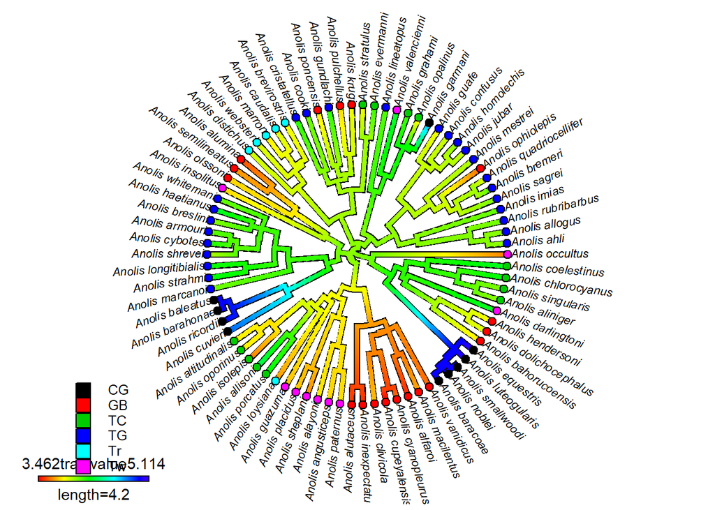

```r
library(geiger)

tree<-read.tree("TutorialData/anole.gp.tre",tree.names=T)
group<-read.csv('TutorialData/anole.gp.csv', row.names=1, header=TRUE,colClasses=c('factor'))
gp<-as.factor(t(group)); names(gp)<-row.names(group)
svl<-read.csv('TutorialData/anole.svl2.csv', row.names=1, header=TRUE)
svl<-as.matrix(treedata(phy = tree,data = svl,warnings=FALSE)$data)[,1]  #match data to tree

#Plot Data
tree.col<-contMap(tree,svl,plot=FALSE)  #runs Anc. St. Est. on branches of tree
plot(tree.col,type="fan",legend=0.7*max(nodeHeights(tree)),
     fsize=c(0.7,0.9))
cols<-setNames(palette()[1:length(unique(gp))],sort(unique(gp)))
tiplabels(pie=model.matrix(~gp-1),piecol=cols,cex=0.3)
add.simmap.legend(colors=cols,prompt=FALSE,x=0.8*par()$usr[1],
                  y=-max(nodeHeights(tree)-.6),fsize=0.8)
```

Here we see our phylogeny with the continuous body size character (SVL) mapped to the branches, and displayed as a heat map. We also have several groups that define habitat use (ecomorphs). These are displayed at the tips of the phylogeny.

#### **BM1: Brownian motion (one group)**

A useful null model of evolutionary change is Brownian motion. For continuous characters, this is considered a *neutral* model, in the sense that there is no selection included: it simply represents random perturbations of the trait over time. This is akin to what might be expected under random genetic drift. The model assumes that changes are independent from time step to time step, so variance increases over time, but the mean does not change. An example is below:

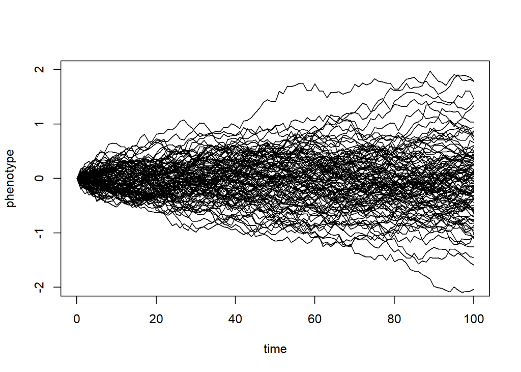

```r
 nsim <- 100
  t <- 0:100  # time
  sig2 <- 0.005
  X <- matrix(rnorm(n = nsim * (length(t) - 1), sd = sqrt(sig2)), nsim, length(t) - 1)
  X <- cbind(rep(0, nsim), t(apply(X, 1, cumsum)))
  plot(t, X[1, ], xlab = "time", ylab = "phenotype", ylim = c(-2, 2), type = "l")
  apply(X[2:nsim, ], 1, function(x, t) lines(t, x), t = t)
```

Many phylogenetic comparative methods (PCMs) for continuous trait data have Brownian motion as their underlying model. For instance, methods for phylogenetic regression (phylogenetically independent contrasts, phylogenetic generalized least squares, phylogenetic transform), and methods for ancestral state estimation of continuous data (maximum likelihood, squared change parsimony) are all based on the Brownian model. To fit this model in R, we do the following:

```r
fit.BM1<-fitContinuous(tree, svl, model="BM")  #Brownian motion model
fit.BM1
```

```
## GEIGER-fitted comparative model of continuous data
##  fitted 'BM' model parameters:
##  sigsq = 0.018223
##  z0 = 4.053507
##
##  model summary:
##  log-likelihood = 5.256010
##  AIC = -6.512019
##  AICc = -6.360121
##  free parameters = 2
##
## Convergence diagnostics:
##  optimization iterations = 100
##  failed iterations = 0
##  frequency of best fit = 1.00
##
##  object summary:
##  'lik' -- likelihood function
##  'bnd' -- bounds for likelihood search
##  'res' -- optimization iteration summary
##  'opt' -- maximum likelihood parameter estimates
```

Notice that fitting the data to the phylogeny under the BM1 model provides the likelihood of that fit, its corresponding AIC (and AICc), as well as the parameters of the Brownian motion model: the rate parameter (sigma2), which describes the *pace* of evolutionary change (how fast the trait evolves along the phylogeny), and the phylogenetic mean (the estimate at the root of the phylogeny).

#### **OU1: Ornstein-Uhlenbeck Model with a single optimum**

Many times, a more realistic model is one containing both selection and drift. This may be found in an OU model. Here, the drift parameter remains, but there is also a selective ‘pull’ towards an optimum. The further the trait value is from the optimum, the stronger the pull. One can view the consequences of this model with the following simulations: first where the starting value and the optimum are the same (demonstrates the constraining force of the OU), and second when the starting value and optimum are not the same:

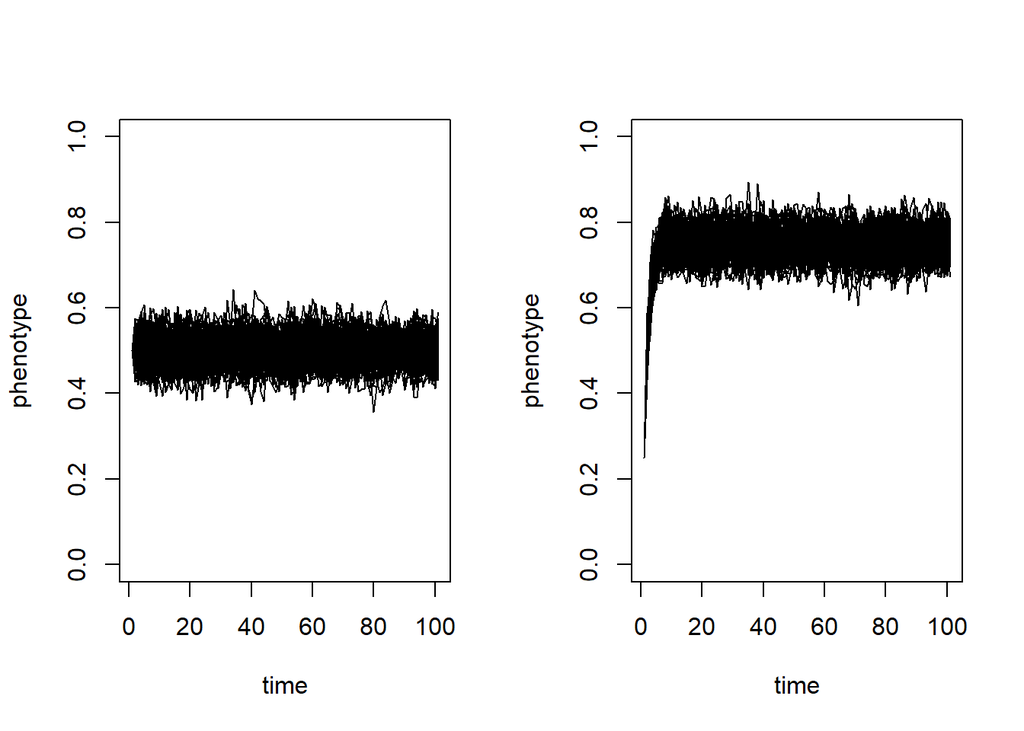

```r
#from Lars Shmitz tutorial: http://schmitzlab.info/BMandOU.html
  OU.sim <- function(n, theta, alpha, sigma,x0){
    dw  <- rnorm(n, 0)
    x <- c(x0)
    for (i in 2:(n+1)) {
      x[i]  <-  x[i-1] + alpha*(theta-x[i-1]) + sigma*dw[i-1]
    }
    return(x);
  }
  OU1.sim1 <- replicate(100, OU.sim(n=100, theta=0.5, alpha=0.5, sigma=0.03, x0=0.5), simplify=FALSE) #No change
  OU1.sim2 <- replicate(100, OU.sim(n=100, theta=0.75, alpha=0.5, sigma=0.03, x0=0.25), simplify=FALSE) #start and theta differ
  par(mfcol = c(1, 2))
  plot(OU1.sim1[[1]],xlab = "time", ylab = "phenotype", ylim = c(0,1), type = "l")
    for(i in 2:100){lines(OU1.sim1[[i]])}
  plot(OU1.sim2[[1]],xlab = "time", ylab = "phenotype", ylim = c(0,1), type = "l")
    for(i in 2:100){lines(OU1.sim2[[i]])}
```

```r
  par(mfcol = c(1,1))
```

Notice the impotant components of the OU model as illustrated here. First, unlike BM where variation increases proportional to time, the OU model displays ‘constrained’ variation over time. This is because of the ‘pull’ of selection to the optimum. Second, if the starting value differs from the optimum, there is a shift of the mean over time. This further illustrates the power of selection in this model. To fit an OU1 model for our data, we do the following:

```r
options(warn=-1)
fit.OU1<-fitContinuous(tree, svl,model="OU")    #OU1 model
fit.OU1
```

```
## GEIGER-fitted comparative model of continuous data
##  fitted 'OU' model parameters:
##  alpha = 0.000000
##  sigsq = 0.018223
##  z0 = 4.053507
##
##  model summary:
##  log-likelihood = 5.256011
##  AIC = -4.512022
##  AICc = -4.204330
##  free parameters = 3
##
## Convergence diagnostics:
##  optimization iterations = 100
##  failed iterations = 60
##  frequency of best fit = NA
##
##  object summary:
##  'lik' -- likelihood function
##  'bnd' -- bounds for likelihood search
##  'res' -- optimization iteration summary
##  'opt' -- maximum likelihood parameter estimates
```

As before, the logL, AIC, and parameter estimates are returned. Armed with these, one may compare the OU1 fit to the null-model BM1. This is accomplished using either using a likelihood ratio test (LRT), or by comparing AIC values (recall a difference > 4 is usually treated as supporting the alternative model).

```r
LRT<-(2*(fit.BM1$opt$lnL-fit.OU1$opt$lnL))
prob<-pchisq(LRT, 1, lower.tail=FALSE)
LRT
```

```
## [1] -2.732714e-06
```

```r
prob
```

```
## [1] 1
```

```r
fit.BM1$aic
```

[output not shown]

```r
fit.OU1$aic
```

[output not shown]

Here we find that under the OU1 model, the fit of the data to the phylogeny is not significantly improved. Thus we prefer the simpler model.

#### **Other models**

There are many alternative models that can be envisioned; many of which are easily implemented. In the category of ‘single group’ models, several common ones include:

1. Brownian motion with a directional trend
2. Early-burst models (rapid trait diversification early in clade history)
3. Lambda models (covaration of phylogeny and trait change)
4. Kappa models (trait change is puncutational and tends to occur at speciation events)

Models 2,3, and 4 are accomplished by adjusting the branch lengths of the phylogeny in some manner. As before, models are fit and then compared using AIC.

```r
fit.BMtrend<-fitContinuous(tree, svl, model="trend")   #Brownian motion with a trend
fit.EB<-fitContinuous(tree, svl, model="EB")   #Early-burst model
fit.lambda<-fitContinuous(tree, svl,
        bounds = list(lambda = c(min = exp(-5), max = 2)), model="lambda")  #Lambda model
options(warn=-1)
fit.K<-fitContinuous(tree, svl, model="kappa")   #Early-burst model

c(fit.BM1$opt$aic,fit.BMtrend$opt$aic,fit.EB$opt$aic,fit.lambda$opt$aic,fit.OU1$opt$aic)
```

```
## [1] -6.512019 -6.981431 -7.235181 -5.517514 -4.512022
```

```r
  #NOTE: none of these generate dAIC > 4.  So go with simplest model (BM1)
```

#### **OUM: Multi-group OU model**

The above evolutionary models all assume that the taxa belong to a single ‘group.’ However, there may be more than one evolutionary optimum, and species may be evolving towards these optima. This requires and OUM approach (multi-group OU model). By convention, groups are referred to as *regimes*. The first step is to assign branches to regimes; commonly known as ‘painting’ the regimes on the tree. This may be done using some explicit biological hypothesis (e.g., ancestral branches are assumed to be one phenotype, while extant taxa belong to one or more groups). Alternatively, one may use ancestral state estimation to assign ancestral regimes, and then assign branches based on these and some rule of state change. Several examples of both are in Butler & King (2004).

Another approach is to use stochastic mapping, which is used here:

```r
library(OUwie)
data<-data.frame(Genus_species=names(svl),Reg=gp,X=svl)  #input data.frame for OUwie

fitBM1<-OUwie(tree,data,model="BM1",simmap.tree=TRUE)
```

```
## Initializing...
## Finished. Begin thorough search...
## Finished. Summarizing results.
```

```r
fitOU1<-OUwie(tree,data,model="OU1",simmap.tree=TRUE)
```

```
## Initializing...
## Finished. Begin thorough search...
## Finished. Summarizing results.
```

```r
  tree.simmap<-make.simmap(tree,gp)  # perform & plot stochastic maps (we would normally do this x100)
```

```
## make.simmap is sampling character histories conditioned on the transition matrix
##
## Q =
##             CG          GB          TC          TG          Tr          Tw
## CG -0.05727086  0.02402046  0.03325041  0.00000000  0.00000000  0.00000000
## GB  0.02402046 -0.20033584  0.04238090  0.06009257  0.01341266  0.06042925
## TC  0.03325041  0.04238090 -0.13585694  0.00000000  0.02427579  0.03594984
## TG  0.00000000  0.06009257  0.00000000 -0.06009257  0.00000000  0.00000000
## Tr  0.00000000  0.01341266  0.02427579  0.00000000 -0.03768845  0.00000000
## Tw  0.00000000  0.06042925  0.03594984  0.00000000  0.00000000 -0.09637910
## (estimated using likelihood);
## and (mean) root node prior probabilities
## pi =
##        CG        GB        TC        TG        Tr        Tw
## 0.1666667 0.1666667 0.1666667 0.1666667 0.1666667 0.1666667
```

```
## Done.
```

```r
fitOUM<-OUwie(tree.simmap,data,model="OUM",simmap.tree=TRUE)
```

```
## Initializing...
## Finished. Begin thorough search...
## Finished. Summarizing results.
```

```r
fitBM1
```

```
##
## Fit
##       lnL       AIC     AICc model ntax
##  5.256014 -6.512029 -6.36013   BM1   82
##
## Rates
##                  CG         GB         TC         TG         Tr         Tw
## alpha            NA         NA         NA         NA         NA         NA
## sigma.sq 0.01822338 0.01822338 0.01822338 0.01822338 0.01822338 0.01822338
##
## Optima
##                 CG GB TC TG Tr Tw
## estimate 4.0535069  0  0  0  0  0
## se       0.1010041  0  0  0  0  0
##
## Arrived at a reliable solution
```

```r
fitOU1
```

```
##
## Fit
##      lnL      AIC      AICc model ntax
##  5.25601 -4.51202 -4.204327   OU1   82
##
## Rates
##                    CG           GB           TC           TG           Tr
## alpha    4.025546e-09 4.025546e-09 4.025546e-09 4.025546e-09 4.025546e-09
## sigma.sq 1.822254e-02 1.822254e-02 1.822254e-02 1.822254e-02 1.822254e-02
##                    Tw
## alpha    4.025546e-09
## sigma.sq 1.822254e-02
##
##
## Optima
##                 CG        GB        TC        TG        Tr        Tw
## estimate 4.0535069 4.0535069 4.0535069 4.0535069 4.0535069 4.0535069
## se       0.1010018 0.1010018 0.1010018 0.1010018 0.1010018 0.1010018
##
## Arrived at a reliable solution
```

```r
fitOUM  #OUM is strongly preferred (examine AIC)
```

```
##
## Fit
##       lnL       AIC     AICc model ntax
##  24.79395 -33.58791 -31.6153   OUM   82
##
##
## Rates
##                  CG         GB         TC         TG         Tr         Tw
## alpha    0.34621792 0.34621792 0.34621792 0.34621792 0.34621792 0.34621792
## sigma.sq 0.02692419 0.02692419 0.02692419 0.02692419 0.02692419 0.02692419
##
## Optima
##                 CG         GB        TC         TG        Tr        Tw
## estimate 5.2777494 3.86679107 4.1561813 4.11023711 3.8564412 3.7889698
## se       0.1334208 0.05310468 0.1020515 0.07511528 0.1561396 0.1097212
##
## Arrived at a reliable solution
```

#### **BMM: Multi-group BM model**

Alternatively, there may be multiple rates across the phylogeny. For example, one may wish to test the hypothesis that trait evolution is faster in one group as compared to another (e.g., Do traits evolve faster in island taxa than mainland taxa?). Again groups are assigned, BM1 model and BMM models are fit to the data, and compared using LRT and AIC:

```r
BMM.res<-brownie.lite(tree = tree.simmap,x = svl,test="simulation")
BMM.res
```

```
## ML single-rate model:
##  s^2 se  a   k   logL
## value    0.0182  0   4.0535  2   5.256
##
## ML multi-rate model:
##  s^2(CG) se(CG)  s^2(GB) se(GB)  s^2(TC) se(TC)  s^2(TG) se(TG)  s^2(Tr) se(Tr)  s^2(Tw) se(Tw)  a   k   logL
## value    0.0746  0.0933  0.0157  0.01    0.0513  0.1622  0.0075  0   0.0014  0   0.0018  0   4.0512  7   22.9794
##
## P-value (based on simulation): 0.01
##
## R thinks it has found the ML solution.
```

#### **Exploratory Models: Identifying Rate Shifts**

The above multi-group methods (OUM and BMM) are * a priori* methods, in that groups are pre-defined by the evolutionary biologist, and hypotheses tested based on those pre-specified groups. An alternative is to mine the data to identify regions on the phylogeny where putative rate shifts are most evident. Two MCMC Bayesian approaches have been proposed for this (Revell et al. 2012: Eastman et al. 2011). **These methods are highly exploratory, and are found in the functions ‘evol.rate.mcmc’ in *phytools*, and the function ‘rjmcmc.bm’ in *geiger***.

## Practical Question

1: Using the *Anolis* phylogeny and body size data above, fit a BM1 model and obtain an estimate of the phylogenetic mean. Then, use ML-based ancestral state estimation from last week, and obtain the root value. How do they compare?

Upload your code to the assignment center on Canvas